# Time Series Forecasting of UK Gas Consumption using Prophet

Coursework 1

Joshua Amoako

10/3/2026

# Introduction

In this project, we perform a comprehensive analysis of **UK gas consumption** using time series forecasting techniques. In the modern energy landscape, understanding historical consumption patterns is vital for infrastructure planning, pricing strategies, and ensuring energy security.

To achieve this, we utilize **Meta’s Prophet model**, a robust forecasting tool designed to handle the specific challenges of time series data, such as strong seasonal effects and long-term non-linear trends.

# Objectives

The primary goals of this report are:

**Data Exploration**: To visualize and understand the raw historical consumption data.

**Trend Quantification**: To use Linear Regression to find the average growth rate of gas demand.

**Advanced Forecasting**: To implement the Prophet model to predict future consumption patterns.

**Component Decomposition**: To isolate the specific impact of seasonal changes (winter vs. summer) on the UK’s energy needs.

# Dataset Description

The dataset used is **`UKgas`**, which provides quarterly records of gas consumption in the UK, measured in **millions of therms**.

This dataset is a classic example of **“seasonal” data**. Because it is recorded quarterly, we can clearly see the impact of the UK’s climate on energy usage. Gas consumption typically **surges during the colder months** for heating and **drops during the summer**, providing a perfect test case for **time series decomposition**.

# Load Required Packages

```r
library(prophet)
library(zoo)
```

# Data Preparation

Prophet requires a dataframe with two columns:

- `ds` → date
- `y` → observed value

We convert the `UKgas` time series into this format:

```r
gas_data <- data.frame(
  ds = as.Date(as.yearmon(time(UKgas))),
  y = as.numeric(UKgas)
)

head(gas_data)
```

```
##           ds     y
## 1 1960-01-01 160.1
## 2 1960-04-01 129.7
## 3 1960-07-01  84.8
## 4 1960-10-01 120.1
## 5 1961-01-01 160.1
## 6 1961-04-01 124.9
```

# Summary Statistics

Before modeling, we look at the basic distribution of the data to identify the range of consumption values.

```r
summary(gas_data$y)
```

```
##    Min. 1st Qu.  Median    Mean 3rd Qu.    Max.
##    84.8   153.3   220.9   337.6   469.9  1163.9
```

The summary statistics show the “spread” of the data, highlighting the significant difference between the minimum consumption periods (summer) and the maximum peaks (winter).

# Exploratory Data Analysis

Visualizing the raw data allows us to identify the two most important features of this time series: **Trend and Seasonality**.

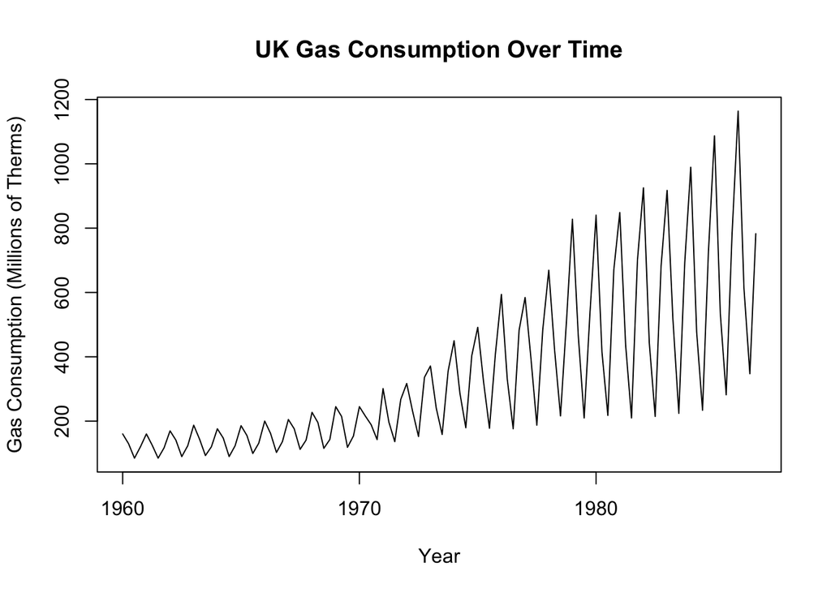

```r
plot(gas_data$ds, gas_data$y, type="l",
     main="UK Gas Consumption Over Time",
     xlab="Year",
     ylab="Gas Consumption (Millions of Therms)")
```

Observations:

- **Upward trend**:There is a visible upward slope, indicating that gas demand increased consistently over several decades.
- **Repeating seasonal fluctuations**: The sharp, repeating “peaks” and “troughs” indicate that consumption is highly dependent on the time of year.

# Linear Trend Analysis

To quantify the long-term growth, we fit a **Simple Linear Regression model**. This allows us to calculate exactly how much gas consumption increases on average every quarter, effectively “straightening out” the seasonal wiggles to see the underlying growth.

The model is defined by the equation:
$$y
= \beta_0 + \beta_1 x + \epsilon$$

```r
time_index <- 1:nrow(gas_data)
trend_model <- lm(y ~ time_index, data = gas_data)
summary(trend_model)
```

```
##
## Call:
## lm(formula = y ~ time_index, data = gas_data)
##
## Residuals:
##     Min      1Q  Median      3Q     Max
## -368.57  -85.50    1.20   69.86  525.95
##
## Coefficients:
##             Estimate Std. Error t value Pr(>|t|)
## (Intercept)  13.5219    32.8558   0.412    0.681
## time_index    5.9469     0.5233  11.364   <2e-16 ***
## ---
## Signif. codes:  0 '***' 0.001 '**' 0.01 '*' 0.05 '.' 0.1 ' ' 1
##
## Residual standard error: 169.5 on 106 degrees of freedom
## Multiple R-squared:  0.5492, Adjusted R-squared:  0.545
## F-statistic: 129.2 on 1 and 106 DF,  p-value: < 2.2e-16
```

**Interpretation:**

- $\beta_1$ gives the **average quarterly increase** in gas consumption.
- $\beta_0$ is the starting level at the first quarter.
- The model confirms a **significant long-term upward trend**.

[figure not shown]

```r
plot(gas_data$ds, gas_data$y, type="l",
     main="UK Gas Consumption with Linear Trend",
     xlab="Year",
     ylab="Gas Consumption")
abline(trend_model, col="red", lwd=2)
```

# Forecasting with Prophet

Prophet models the time series as:

$x(t) = m(t) + s(t) + y(t)$

- $m(t)$ → trend
- $s(t)$ → seasonality
- $y(t)$ → error

We fit the Prophet model:

```r
prophet_model <- prophet(gas_data)
```

```
## Disabling weekly seasonality. Run prophet with weekly.seasonality=TRUE to override this.
```

```
## Disabling daily seasonality. Run prophet with daily.seasonality=TRUE to override this.
```

Next, we create **future dates for forecasting**:

```r
future_dates <- make_future_dataframe(prophet_model, periods=20, freq="quarter")
forecast <- predict(prophet_model, future_dates)

# Inspect forecast
head(forecast)
```

```
##           ds    trend additive_terms additive_terms_lower additive_terms_upper
## 1 1960-01-01 114.6604       82.42081             82.42081             82.42081
## 2 1960-04-01 120.2017     -125.01911           -125.01911           -125.01911
## 3 1960-07-01 125.7431     -263.76878           -263.76878           -263.76878
## 4 1960-10-01 131.3454      -54.15830            -54.15830            -54.15830
## 5 1961-01-01 136.9476       82.66140             82.66140             82.66140
## 6 1961-04-01 142.4281     -124.25046           -124.25046           -124.25046
##       yearly yearly_lower yearly_upper multiplicative_terms
## 1   82.42081     82.42081     82.42081                    0
## 2 -125.01911   -125.01911   -125.01911                    0
## 3 -263.76878   -263.76878   -263.76878                    0
## 4  -54.15830    -54.15830    -54.15830                    0
## 5   82.66140     82.66140     82.66140                    0
## 6 -124.25046   -124.25046   -124.25046                    0
##   multiplicative_terms_lower multiplicative_terms_upper yhat_lower yhat_upper
## 1                          0                          0   62.59685 334.410828
## 2                          0                          0 -151.66355 140.142304
## 3                          0                          0 -278.04899   1.448006
## 4                          0                          0  -63.23695 229.126049
## 5                          0                          0   79.77277 355.229818
## 6                          0                          0 -120.86614 164.231551
##   trend_lower trend_upper        yhat
## 1    114.6604    114.6604  197.081175
## 2    120.2017    120.2017   -4.817374
## 3    125.7431    125.7431 -138.025678
## 4    131.3454    131.3454   77.187060
## 5    136.9476    136.9476  219.609022
## 6    142.4281    142.4281   18.177628
```

**Observation:**  
The forecast includes **predicted values (`yhat`)**, **lower and upper uncertainty bounds**, and **trend/seasonal components**.

# Forecast Visualisation

We visualise the predicted values with uncertainty:

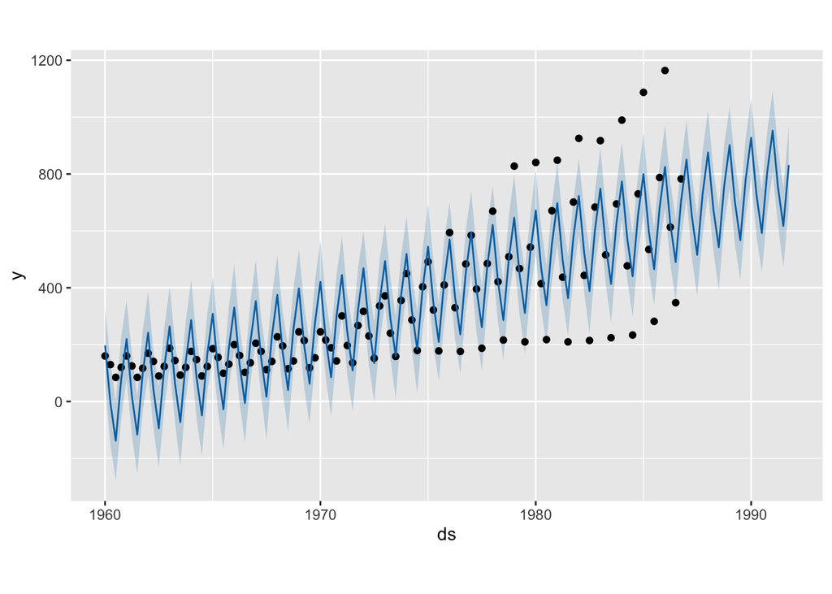

```r
plot(prophet_model, forecast)
```

# Trend and Seasonal Components

One of **Prophet’s best features** is its ability to **“unstack”** the data so we can see what is actually driving the numbers. This turns a complex graph into **two simple, understandable stories**.

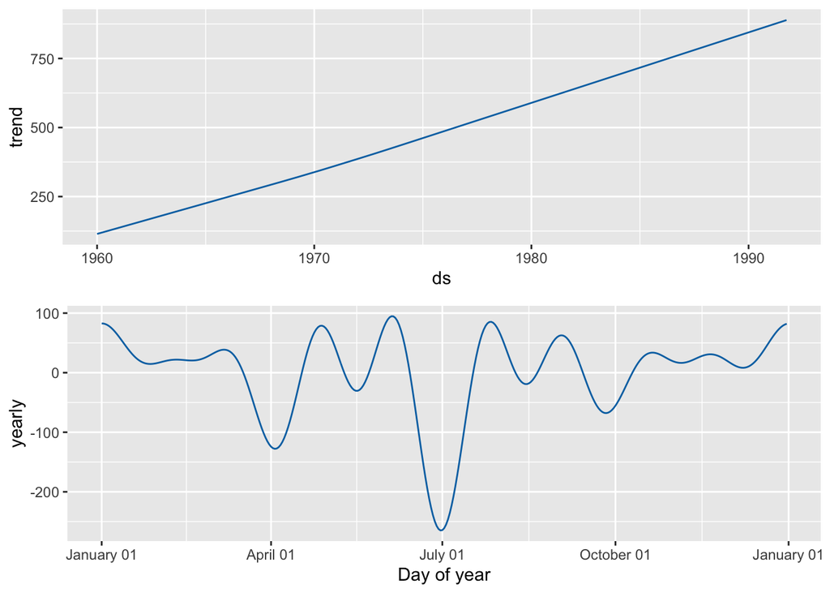

```r
# Plotting the components while suppressing background warnings
prophet_plot_components(prophet_model, forecast)
```

# Discussion and Conclusion

This analysis demonstrates that UK gas consumption is driven by two main forces: a **steady long-term increase** in demand and **extreme seasonal volatility**.

By utilizing the **uncertainty intervals** (the blue shaded regions) provided by Prophet, energy planners can better prepare for **“worst-case” scenarios** in high-demand quarters. This ensures that the UK’s gas infrastructure is prepared not just for the “average” day, but for the **cold winter peaks** where demand is highest.

### Final Summary

In conclusion, this project shows how moving from simple linear models to **advanced decomposition models** like Prophet allows us to turn raw data into **meaningful, visual stories** that can guide real-world decision-making.